# Aprendizaje No Supervisado

### **Matriz de distancias**

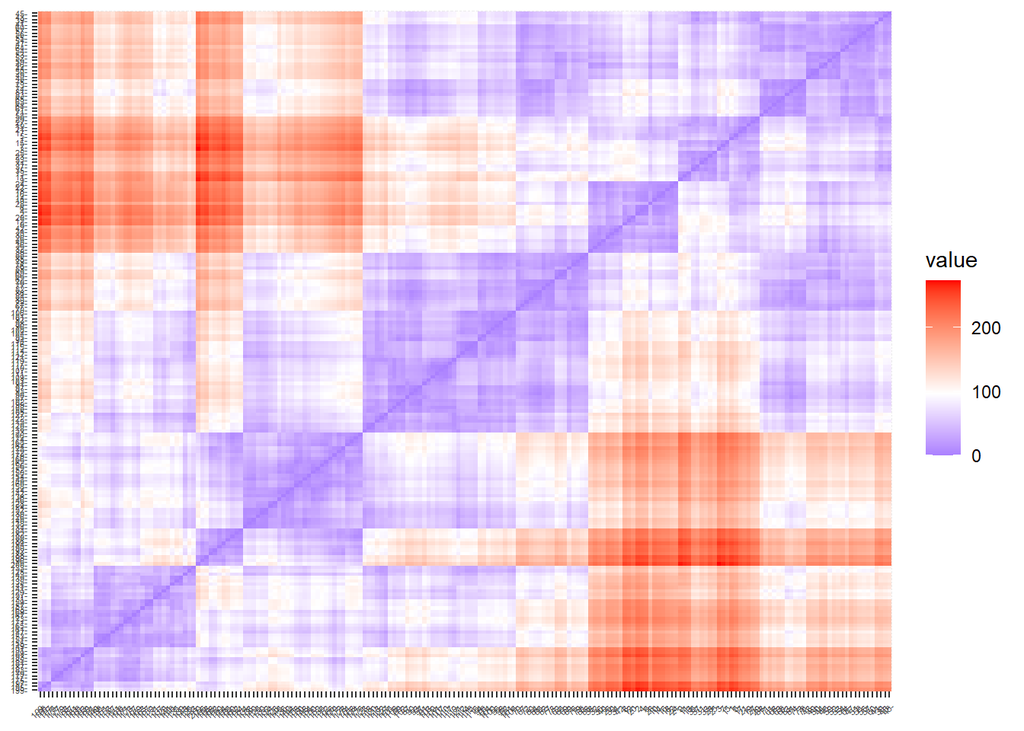

```r
#install.packages("dendextend")
#install.packages("factoextra")

library(dendextend)
library(factoextra)
library(cluster)

# Matriz de distancias euclídeas
mat_dist <- dist(x = dataset, method = "euclidean")  # metodo: "maximum", "manhattan", "canberra", "binary" or "minkowski"
fviz_dist(mat_dist, gradient = list(low = "blue", mid = "white", high = "red"), lab_size = 4)
```

### **Linkage**

#### Completo o Máximo:

La mayor distancia entre todos los posibles pares formados por una observación del Cluster A y una del cluster B. Más conservadora

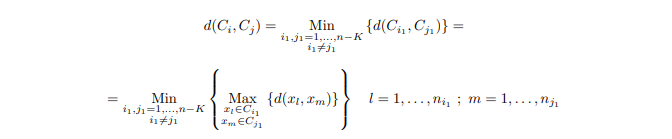

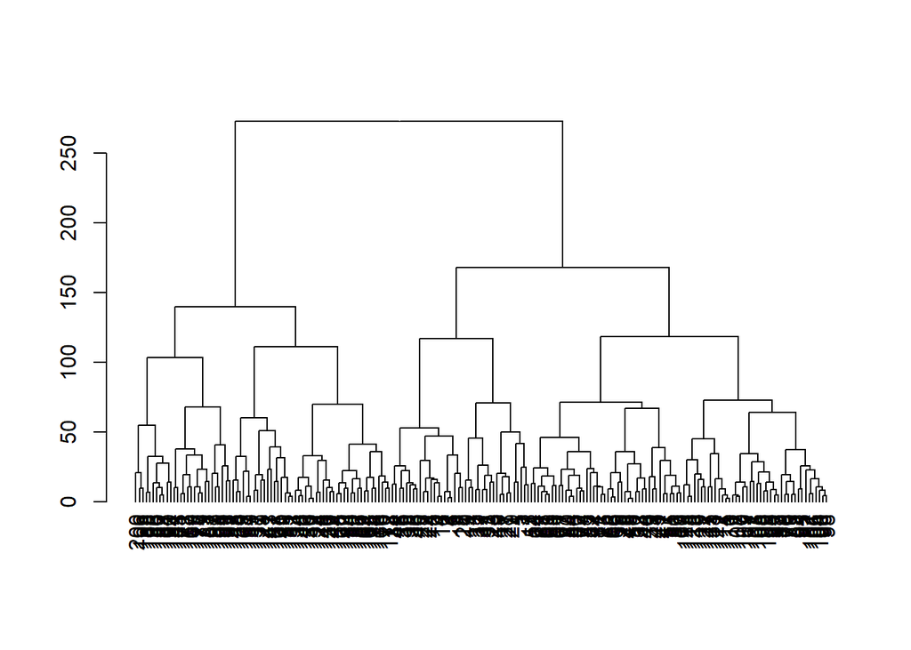

```r
# Dendograma con linkages complete usando libreria "dendextend"
hc_euclidea_complete <- hclust(d = mat_dist, method = "complete")
dend_modelo <- as.dendrogram(hc_euclidea_complete)
plot(dend_modelo)
```

#### Promedio:

El promedio de las distancias entre todos los posibles pares formados por una observación del Cluster A y una del cluster B.

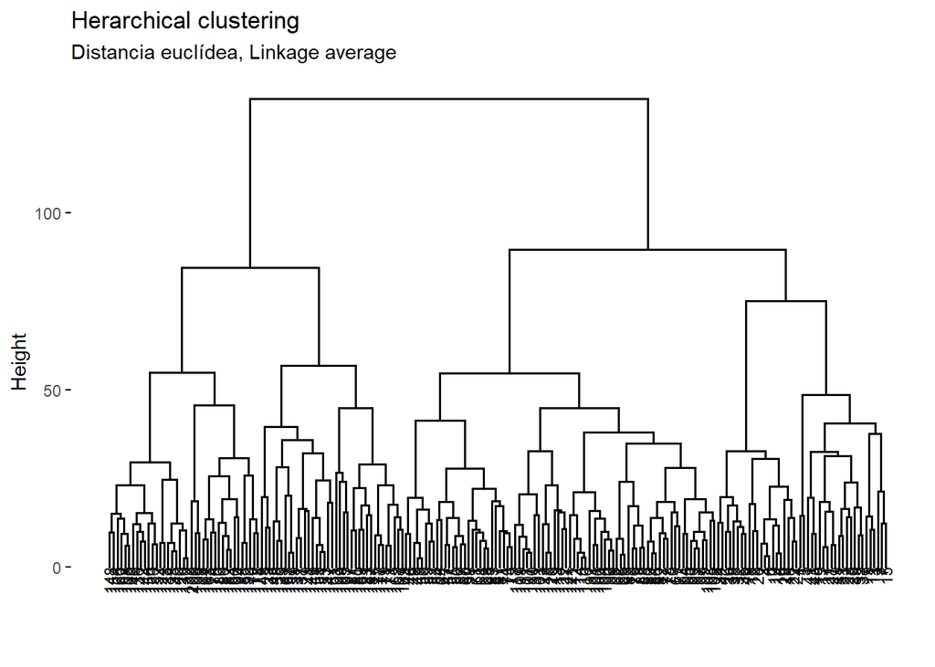

```r
#install.packages("factoextra")
library(factoextra)

# Dendograma con linkages average usando libreria "factoextra"
hc_euclidea_average  <- hclust(d = mat_dist, method = "average")

fviz_dend(x = hc_euclidea_average, cex = 0.6) +
    labs(title = "Herarchical clustering",
       subtitle = "Distancia euclídea, Linkage average")
```

Otras funcionalidades de fviz_dend

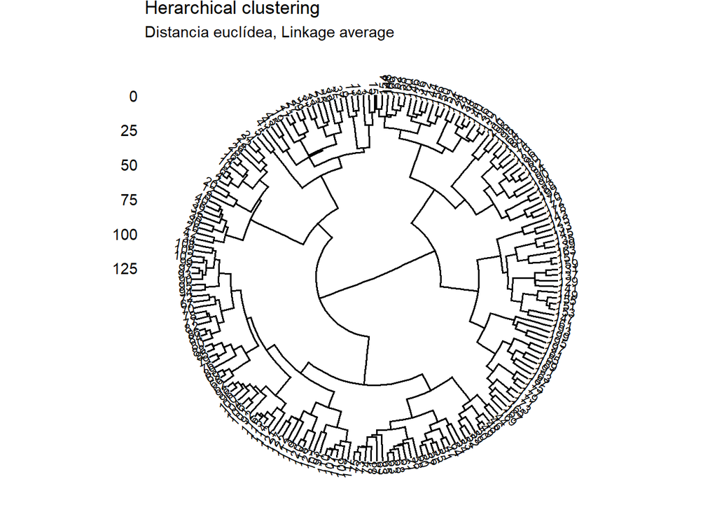

```r
fviz_dend(x = hc_euclidea_average, cex = 0.6, type = "circular") +
    labs(title = "Herarchical clustering",
       subtitle = "Distancia euclídea, Linkage average")
```

#### Centroide:

Distacia entre los centroides de los clusters.

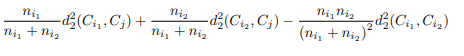

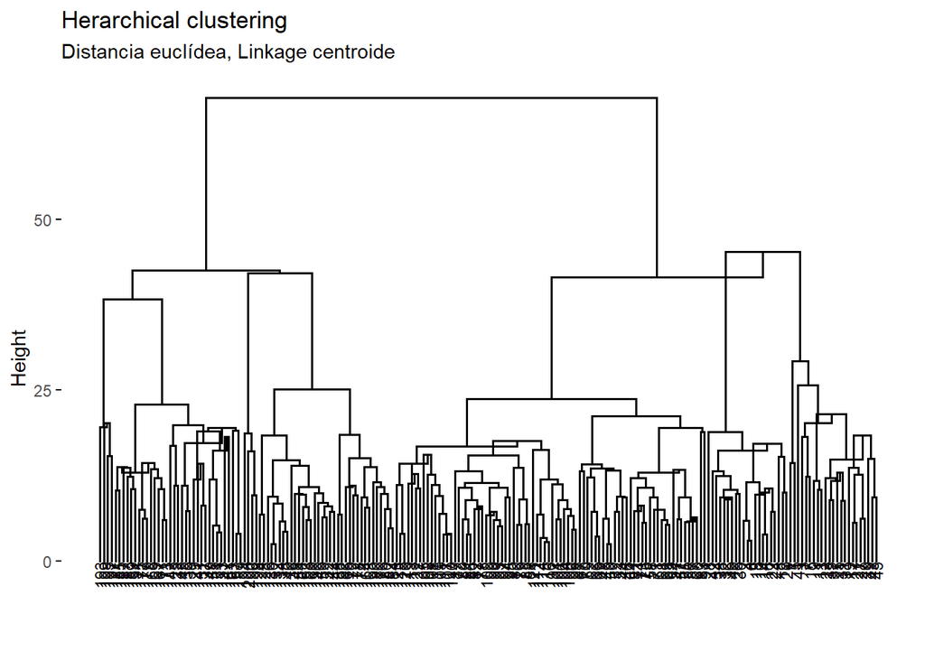

```r
hc_euclidea_centroid  <- hclust(d = mat_dist, method = "centroid")

fviz_dend(x = hc_euclidea_centroid, cex = 0.6) +
    labs(title = "Herarchical clustering",
       subtitle = "Distancia euclídea, Linkage centroide")
```

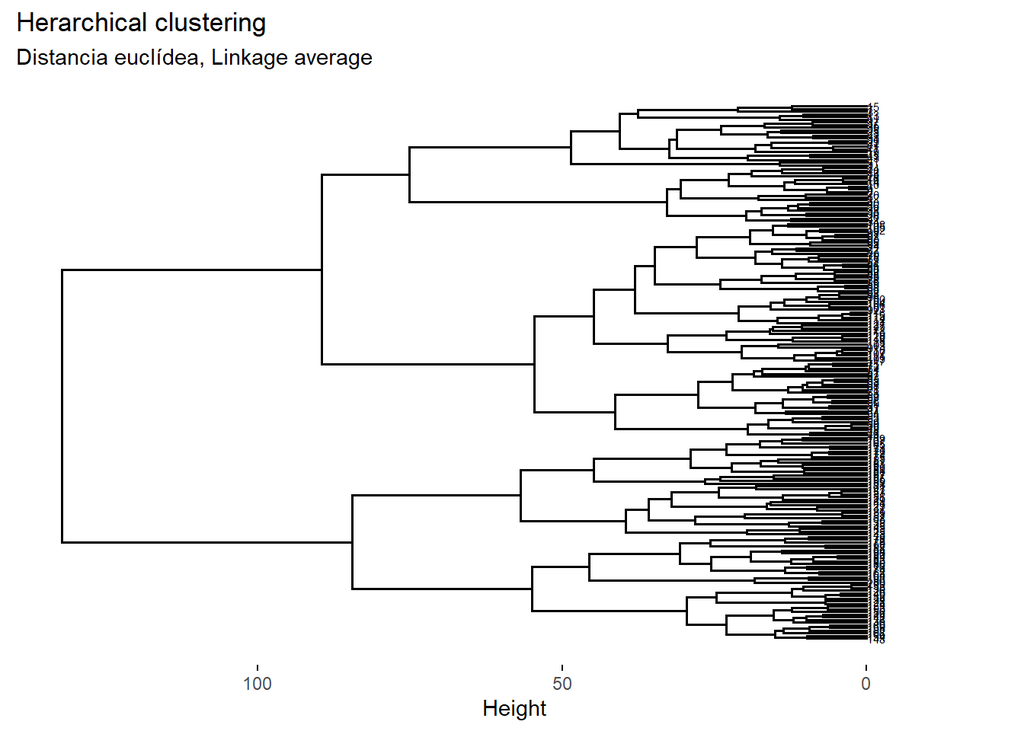

```r
fviz_dend(x = hc_euclidea_average, cex = 0.4, horiz = TRUE) +
    labs(title = "Herarchical clustering",
       subtitle = "Distancia euclídea, Linkage average")
```

#### Ward:

Minimiza la suma total de la varianza dentro del cluster.

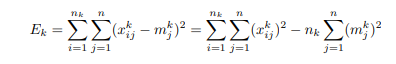

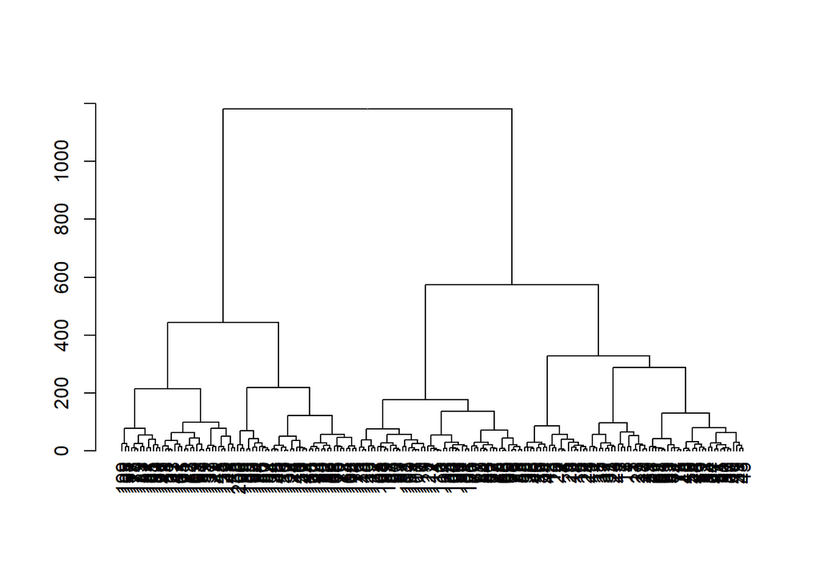

```r
hc_euclidea_ward  <- hclust(d = mat_dist, method = "ward.D2")

dend_modelo <- as.dendrogram(hc_euclidea_ward)
plot(dend_modelo)
```

### **Coeficiente de correlación entre distancias**

Útil para comparar métodos ya que habla de si un dendograma resultante presenta relaciones aceptables al compararlo con la matriz de distancias originales

```r
# Correlación para Linkage completo
cor(x = mat_dist, cophenetic(hc_euclidea_complete))
```

```
## [1] 0.6988938
```

```r
# Correlación para Linkage average
cor(x = mat_dist, cophenetic(hc_euclidea_average))
```

```
## [1] 0.7094375
```

```r
# Correlación para Linkage centroide
cor(x = mat_dist, cophenetic(hc_euclidea_centroid))
```

```
## [1] 0.7047608
```

```r
# Correlación para Linkage Ward
cor(x = mat_dist, cophenetic(hc_euclidea_ward))
```

```
## [1] 0.6880459
```

### **Número de Cluster**

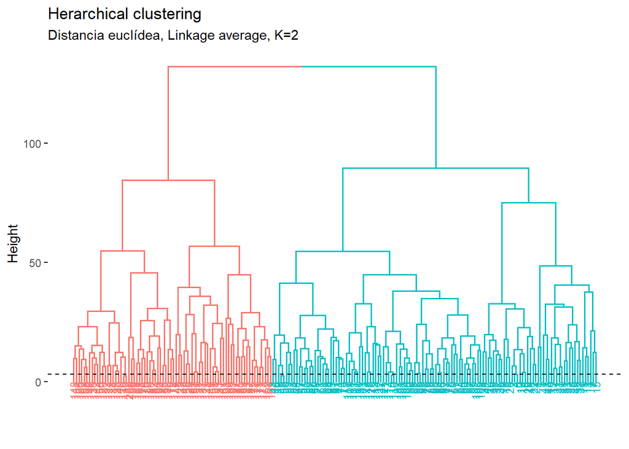

```r
fviz_dend(x = hc_euclidea_average, k = 2, cex = 0.6) +
  geom_hline(yintercept = 3, linetype = "dashed") +
  labs(title = "Herarchical clustering",
       subtitle = "Distancia euclídea, Linkage average, K=2")
```

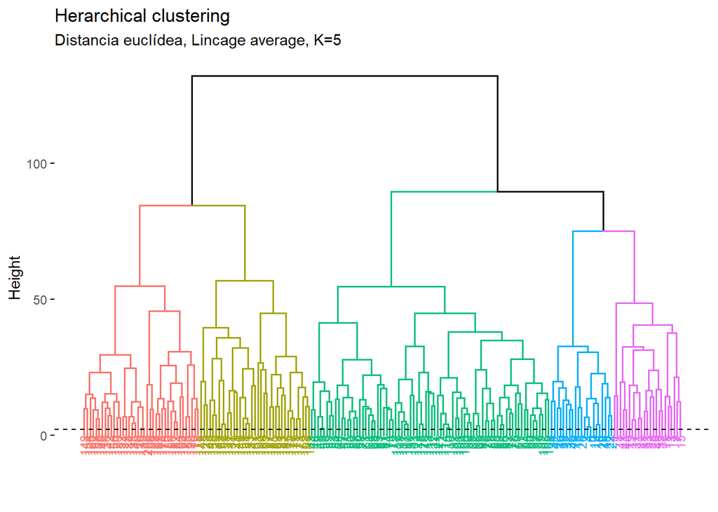

```r
fviz_dend(x = hc_euclidea_average, k = 5, cex = 0.6) +
  geom_hline(yintercept = 2, linetype = "dashed") +
  labs(title = "Herarchical clustering",
       subtitle = "Distancia euclídea, Lincage average, K=5")
```

```r
# tabla de asignación por cluster
cutree(hc_euclidea_average, h = 2)
```

```
##   [1]   1   2   3   4   5   6   7   8   9  10  11  12  13  14  15  16  17  18
##  [19]  19  20  21  22  23  24  25  26  27  28  29  30  31  32  33  34  35  36
##  [37]  37  38  39  40  41  42  43  44  45  46  47  48  49  50  51  52  53  54
##  [55]  55  56  57  58  59  60  61  62  63  64  65  66  67  68  69  70  71  72
##  [73]  73  74  75  76  77  78  79  80  81  82  83  84  85  86  87  88  89  90
##  [91]  91  92  93  94  95  96  97  98  99 100 101 102 103 104 105 106 107 108
## [109] 109 110 111 112 113 114 115 116 117 118 119 120 121 122 123 124 125 126
## [127] 127 128 129 130 131 132 133 134 135 136 137 138 139 140 141 142 143 144
## [145] 145 146 147 148 149 150 151 152 153 154 155 156 157 158 159 160 161 162
## [163] 163 164 165 166 167 168 169 170 171 172 173 174 175 176 177 178 179 180
## [181] 181 182 183 184 185 186 187 188 189 190 191 192 193 194 195 196 197 198
## [199] 199 200
```

```r
# Tamaño de cada cluster
table(cutree(hc_euclidea_average, h = 2))
```

```
##
##   1   2   3   4   5   6   7   8   9  10  11  12  13  14  15  16  17  18  19  20
##   1   1   1   1   1   1   1   1   1   1   1   1   1   1   1   1   1   1   1   1
##  21  22  23  24  25  26  27  28  29  30  31  32  33  34  35  36  37  38  39  40
##   1   1   1   1   1   1   1   1   1   1   1   1   1   1   1   1   1   1   1   1
##  41  42  43  44  45  46  47  48  49  50  51  52  53  54  55  56  57  58  59  60
##   1   1   1   1   1   1   1   1   1   1   1   1   1   1   1   1   1   1   1   1
##  61  62  63  64  65  66  67  68  69  70  71  72  73  74  75  76  77  78  79  80
##   1   1   1   1   1   1   1   1   1   1   1   1   1   1   1   1   1   1   1   1
##  81  82  83  84  85  86  87  88  89  90  91  92  93  94  95  96  97  98  99 100
##   1   1   1   1   1   1   1   1   1   1   1   1   1   1   1   1   1   1   1   1
## 101 102 103 104 105 106 107 108 109 110 111 112 113 114 115 116 117 118 119 120
##   1   1   1   1   1   1   1   1   1   1   1   1   1   1   1   1   1   1   1   1
## 121 122 123 124 125 126 127 128 129 130 131 132 133 134 135 136 137 138 139 140
##   1   1   1   1   1   1   1   1   1   1   1   1   1   1   1   1   1   1   1   1
## 141 142 143 144 145 146 147 148 149 150 151 152 153 154 155 156 157 158 159 160
##   1   1   1   1   1   1   1   1   1   1   1   1   1   1   1   1   1   1   1   1
## 161 162 163 164 165 166 167 168 169 170 171 172 173 174 175 176 177 178 179 180
##   1   1   1   1   1   1   1   1   1   1   1   1   1   1   1   1   1   1   1   1
## 181 182 183 184 185 186 187 188 189 190 191 192 193 194 195 196 197 198 199 200
##   1   1   1   1   1   1   1   1   1   1   1   1   1   1   1   1   1   1   1   1
```

## **Divisive**

Inicia con un único cluster que contiene todas las observaciones, a continuación, se va dividiendo hasta que cada observación forma un cluster independiente. En cada iteración, se selecciona el cluster y la mayor diferencia entre dos de sus observaciones.

**DIANA: DIvisive ANAlysis Clustering** Algoritmo más usado para el método divisive, en este caso no hay Linkage

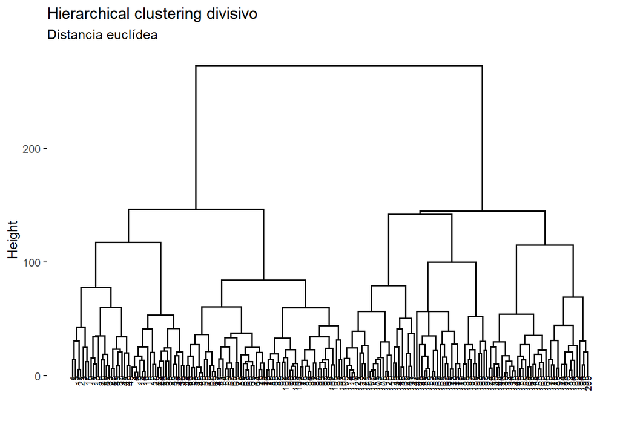

```r
library(cluster)
hc_diana <- diana(x = mat_dist, diss = TRUE, stand = FALSE)

fviz_dend(x = hc_diana, cex = 0.5) +
  labs(title = "Hierarchical clustering divisivo",
       subtitle = "Distancia euclídea")
```

```r
# Correlación para Linkage average
cor(x = mat_dist, cophenetic(hc_diana))
```

```
## [1] 0.6924129
```